# R ile Veri Analizinde *Tidyverse* Yaklaşımı

## 4.1 Çizgi grafiği

Örnek: Türkiye’nin kişi başına GDP değerlerinin zaman serisi grafiğini çiz.

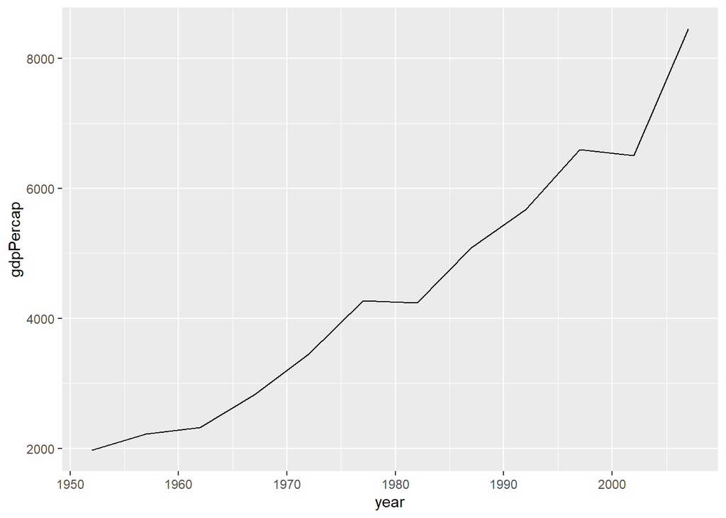

```r
library(gapminder)
# verileri oluştur
turkey <- gapminder %>% filter(country=="Turkey")
# grafiği çiz
ggplot(turkey, aes(x = year, y = gdpPercap)) +
  geom_line()
```

Yatay ve dikey eksenlerin etiketlerini ve grafik başlığını ekleyelim. Ayrıca gözlem noktalarını da ekleyelim:

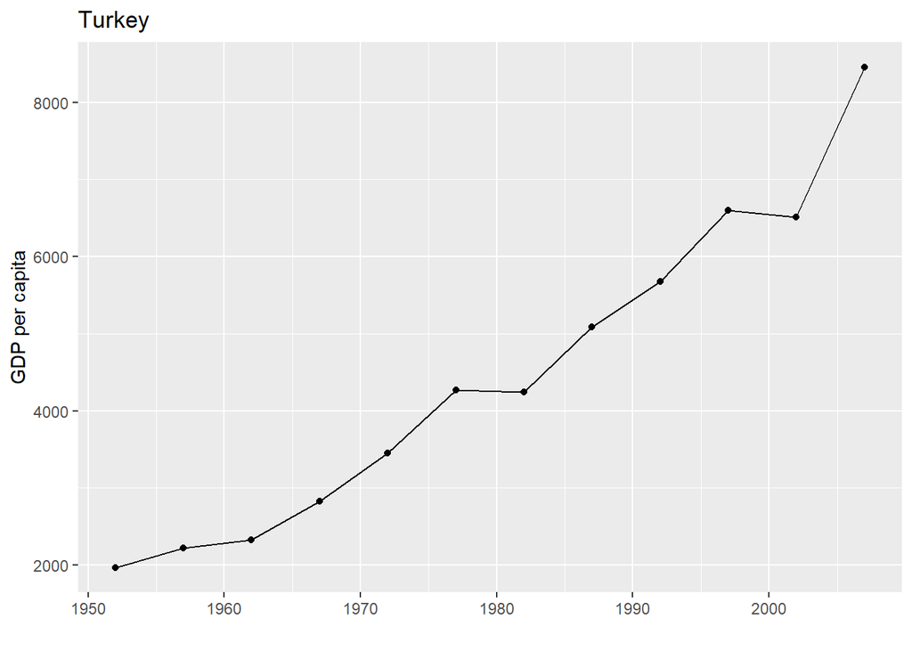

```r
library(gapminder)
turkey <- gapminder %>% filter(country=="Turkey")
ggplot(turkey, aes(x = year, y = gdpPercap)) +
  geom_line() +
  geom_point() +
  xlab("") +
  ylab("GDP per capita") +
  ggtitle("Turkey")
```

Örnek: Düşük gelirli Avrupa ülkelerinde yaşam beklentisinin zaman serisi grafiğini çiz. Düşük gelir durumu: 2007 yılında gdpPercap<10000 ise düşük gelirli ülke; değilse yüksek gelirli ülke.

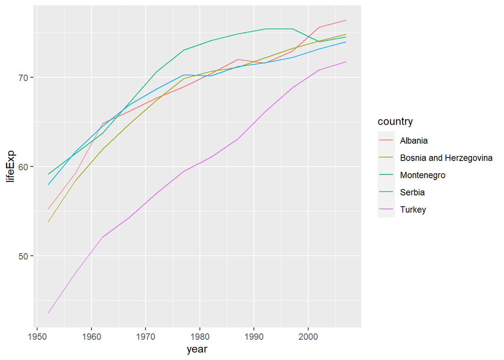

```r
# verileri oluştur
europe <- gapminder %>%
  filter(continent == "Europe")
clist <- filter(europe, gdpPercap<10000 & year==2007)
lowincome_europe <- filter(europe, country %in% clist$country)
# grafiği çiz
ggplot(lowincome_europe, aes(x = year, y = lifeExp, color = country)) +
  geom_line()
```

Aynı grafiğin siyah-beyaz versiyonu:

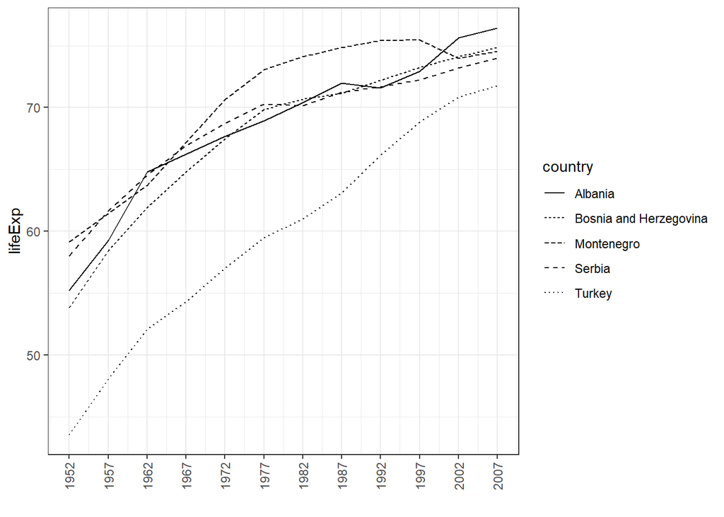

```r
ggplot(lowincome_europe, aes(x = year, y = lifeExp, linetype = country)) +
  geom_line() +
  theme_bw() +
  scale_x_continuous(breaks=seq(1952,2007,5)) +
  theme(axis.text.x = element_text(angle = 90, vjust = 0.5, hjust = 1)) +
  xlab("")
```

## 4.2 Histogram

Sürekli değişkenlerin dağılımlarının görselleştirilmesinde en yaygın kullanılan araçlardan biri histogramdır. `geom_histogram()` fonksiyonu ile histogramı çizebiliriz. Örneğin:

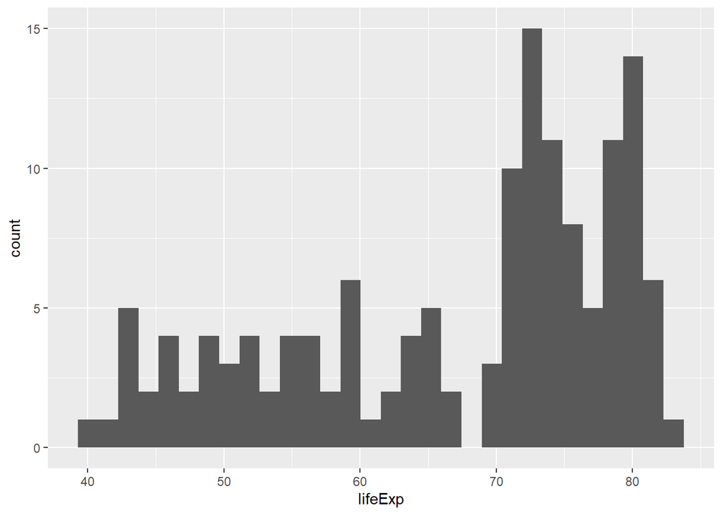

```r
y2007 <- filter(gapminder, year==2007)
ggplot(data = y2007 ) +
geom_histogram(mapping = aes(x = lifeExp))
```

Histogram çiziminde en önemli tercih sınıf sayısıdır (bin). Kullanıcı tarafından verilere uygun bin sayısının tercih edilmesi gerekir. Yukarıdaki histogramda çubuklar arasında boşluklar olduğunu görüyoruz. Sınıf sayısı gereğinden fazla gibi görünüyor. Default değer bins=30 yerine 15 ile yeniden çizelim:

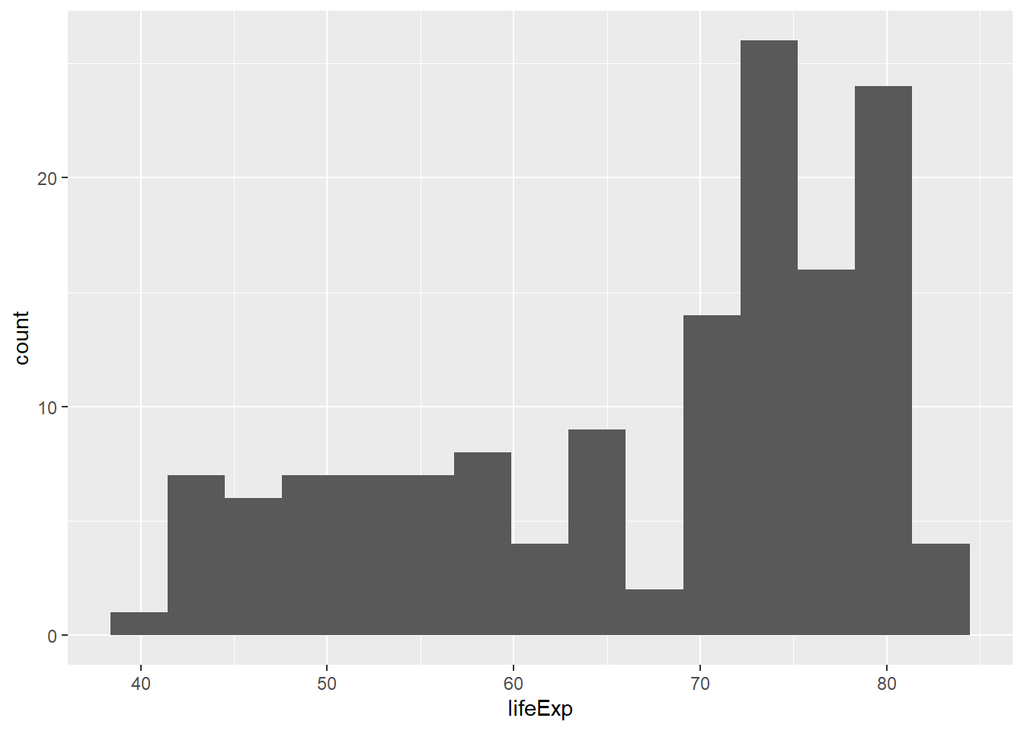

```r
ggplot(data = y2007 ) +
  geom_histogram(mapping = aes(x = lifeExp), bins = 15)
```

Yaşam beklentisinin iki modlu bir dağılıma sahip olduğunu görüyoruz.

**Örnek**: Tüm verileri kullanarak yaşam beklentisinin histogramını çizelim:

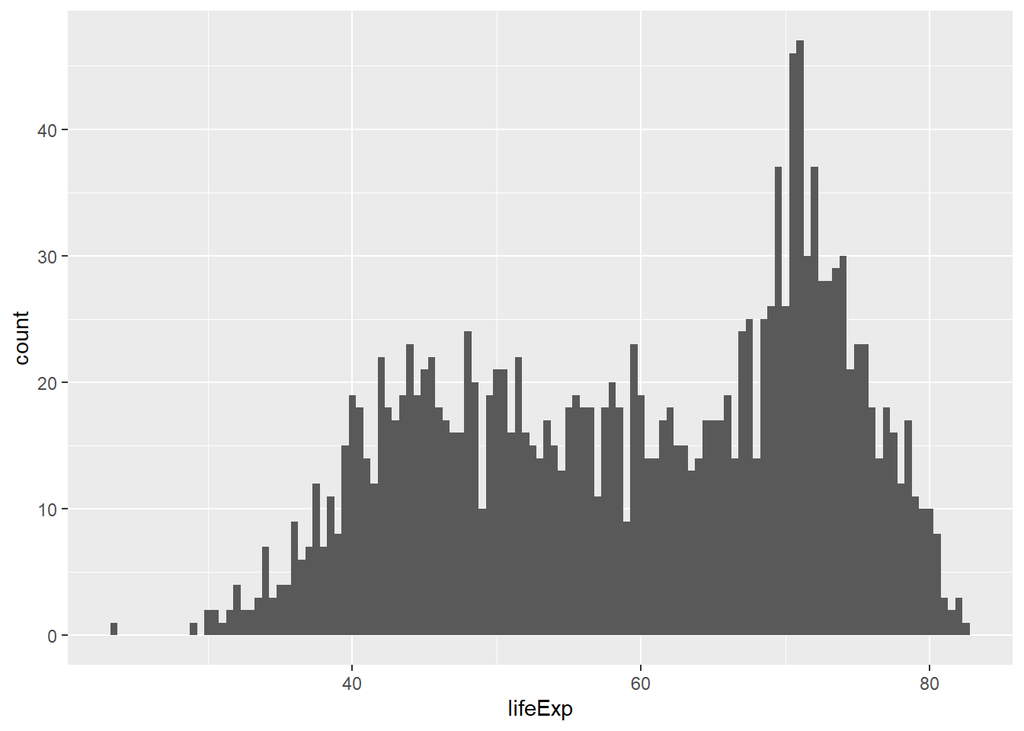

```r
library(gapminder)
ggplot(data =gapminder ) +
  geom_histogram(mapping = aes(x = lifeExp), binwidth = 0.5)
```

**Örnek**: Verileri oluşturalım:

```r
set.seed(1)
n <- 200
notlar1 <- round(rnorm(n, mean = 50, sd = 10))
notlar2 <- round(rnorm(n, mean = 60, sd = 15))
notlar3 <- round(rnorm(n, mean = 70, sd = 12))
ders <-  factor( rep(c("Ekonometri-1","Ekonometri-2","Makine Öğrenmesi"), each=n) )
not_verileri <- tibble(ders,
                       not = c(notlar1, notlar2, notlar3),
                       cinsiyet = sample(c("Kadın", "Erkek"), 3*n, replace = TRUE))
not_verileri <- filter(not_verileri, not<=100 & not>=0)
head(not_verileri)
```

```
## # A tibble: 6 x 3
##   ders           not cinsiyet
##   <fct>        <dbl> <chr>
## 1 Ekonometri-1    44 Kadın
## 2 Ekonometri-1    52 Erkek
## 3 Ekonometri-1    42 Kadın
## 4 Ekonometri-1    66 Erkek
## 5 Ekonometri-1    53 Kadın
## 6 Ekonometri-1    42 Erkek
```

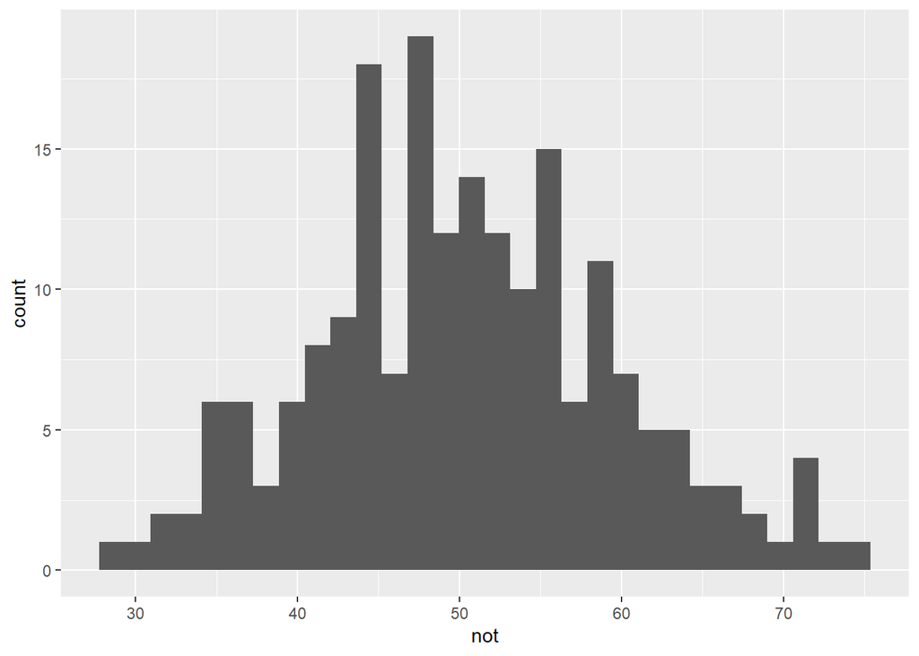

```r
not_verileri %>% filter(ders == "Ekonometri-1") %>%
  ggplot() +
  geom_histogram(mapping = aes(x = not))
```

Histogramın default değerleri pek göze hitap etmiyor, sınıflar birbiriyle kaynaşmış ve sınıf sayısı da optimal değil. Yeniden çizelim:

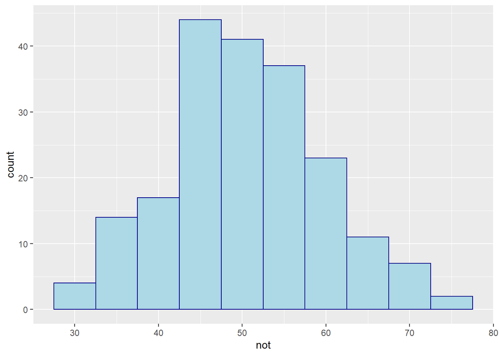

```r
not_verileri %>% filter(ders == "Ekonometri-1") %>%
  ggplot(mapping = aes(x = not)) +
  geom_histogram(binwidth = 5,       # sütun genişliği
                 color = "darkblue",  # sütun sınırlarının rengi
                 fill = "lightblue"   # sütun içinin rengi
                 )
```

Diğer dersler için de histogramları çizelim ve yan yana paneller oluşturalım:

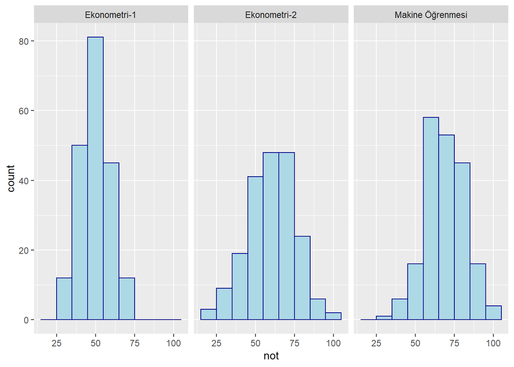

```r
ggplot(data = not_verileri) +
  geom_histogram(mapping = aes(x = not),
                 binwidth = 10,
                 color = "darkblue",
                 fill  = "lightblue"
                 ) +
  facet_wrap(~ ders)
```

## 4.3 Kutu grafiği (Box Plot)

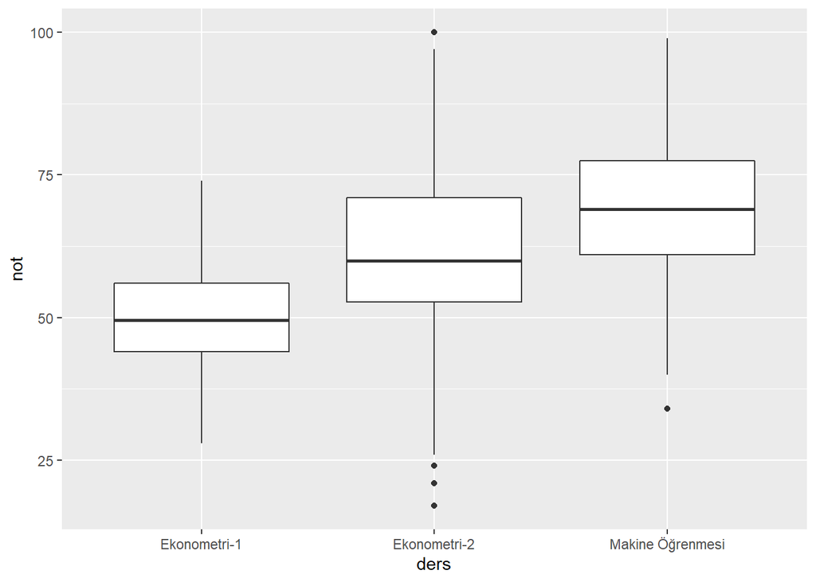

```r
ggplot(data = not_verileri) +
  geom_boxplot(mapping = aes(x = ders, y=not))
```

**Örnek:** Gapminder veri setinde yaşam beklentisinin kıtalara göre kutu çizimi.  
over continents

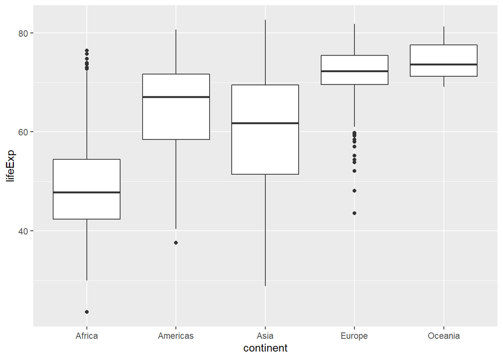

```r
ggplot(data = gapminder, mapping = aes(x = continent, y = lifeExp)) +
  geom_boxplot()
```

## 4.4 Nokta grafiği (dot plot)

Elimizde bir kategorik değişken ve bir nümerik değer varsa `geom_point()` kullanılabilir.

**Örnek**: Avrupa’da 2007 yılındaki yaşam beklentisi küçükten büyüğe sıralayıp nokta grafiğini çiz.

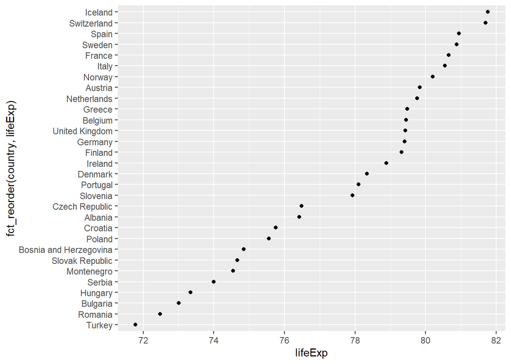

```r
# önce verileri oluştur
europe2007 <- gapminder %>%
  filter(year == 2007, continent == "Europe")
# grafiği çiz
ggplot(europe2007, aes(x = lifeExp, y = fct_reorder(country, lifeExp))) +
  geom_point()
```

## 4.5 Serpilme çizimi (Scatter plots)

**Örnek**: Gapminder veri setinde kişi başına gelir ve yaşam beklentisi:

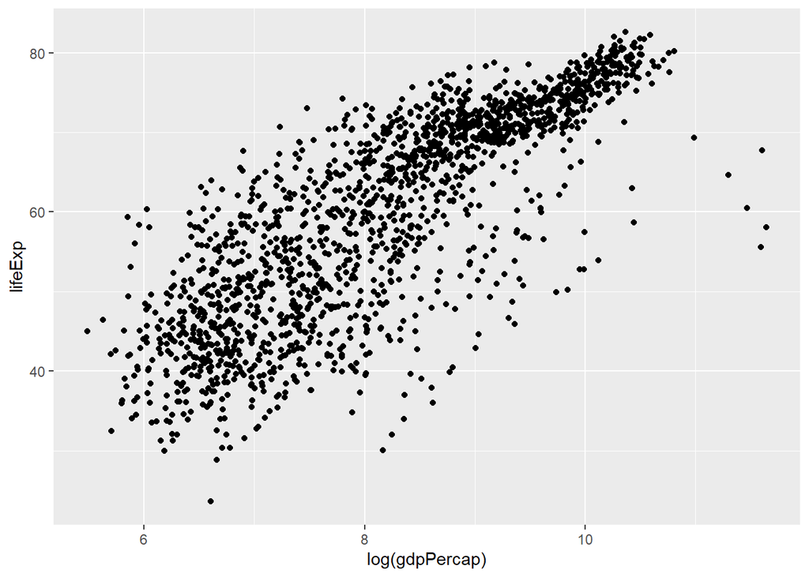

```r
library(gapminder)
ggplot(gapminder, aes(x=log(gdpPercap),y=lifeExp)) +
      geom_point()
```

**Örnek**: Kıta bilgisini renk estetiğni kullanarak ekleyelim:

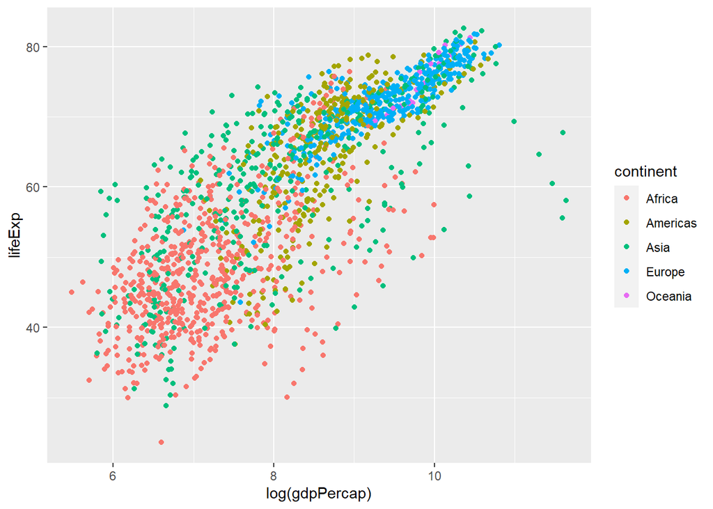

```r
splot1 <- ggplot(gapminder, aes(x=log(gdpPercap),y=lifeExp)) +
             geom_point(aes(color=continent))
splot1
```

**Örnek**: Önceki grafiğin temasını siyah-beyaz olarak değiştirelim.

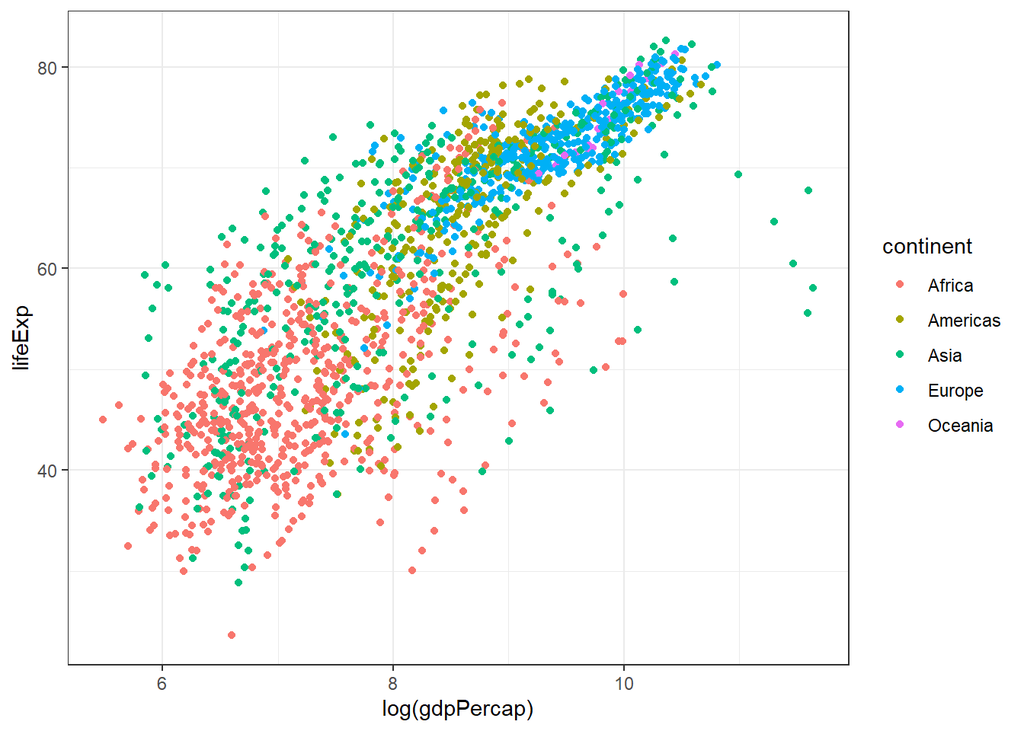

```r
ggplot(gapminder, aes(x=log(gdpPercap),y=lifeExp)) +
      geom_point(aes(color=continent)) +
      theme_bw()
```

ya da

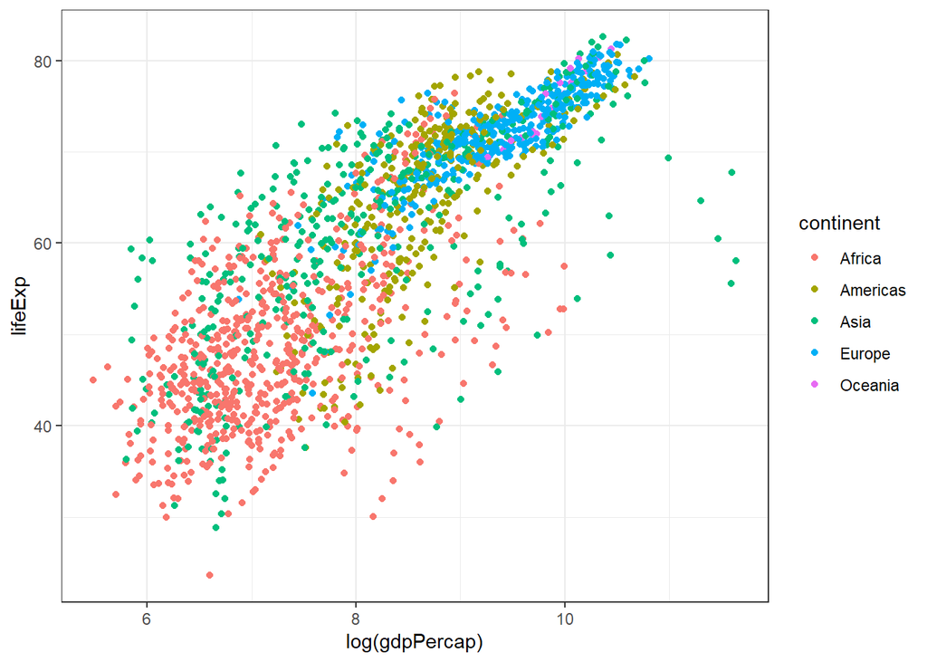

```r
splot1 + theme_bw()
```

**Alıştırma**: Önceki grafiği sadece 2002 yılı için çiziniz.

**Örnek**: Alt grafiklerin oluşturlması (**facets**).

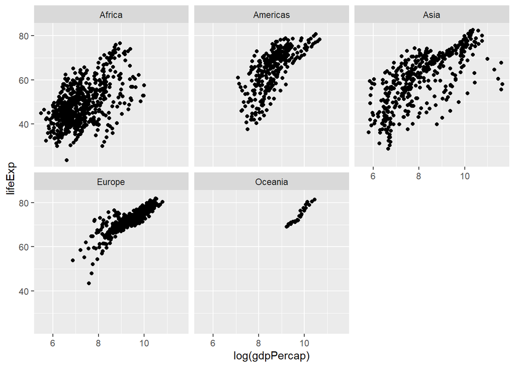

```r
ggplot(gapminder, aes(x=log(gdpPercap),y=lifeExp)) +
      geom_point() +
      facet_wrap(~ continent, nrow=2)
```

**Örnek**: Yılın facet değişkeni olarak kullanılması:

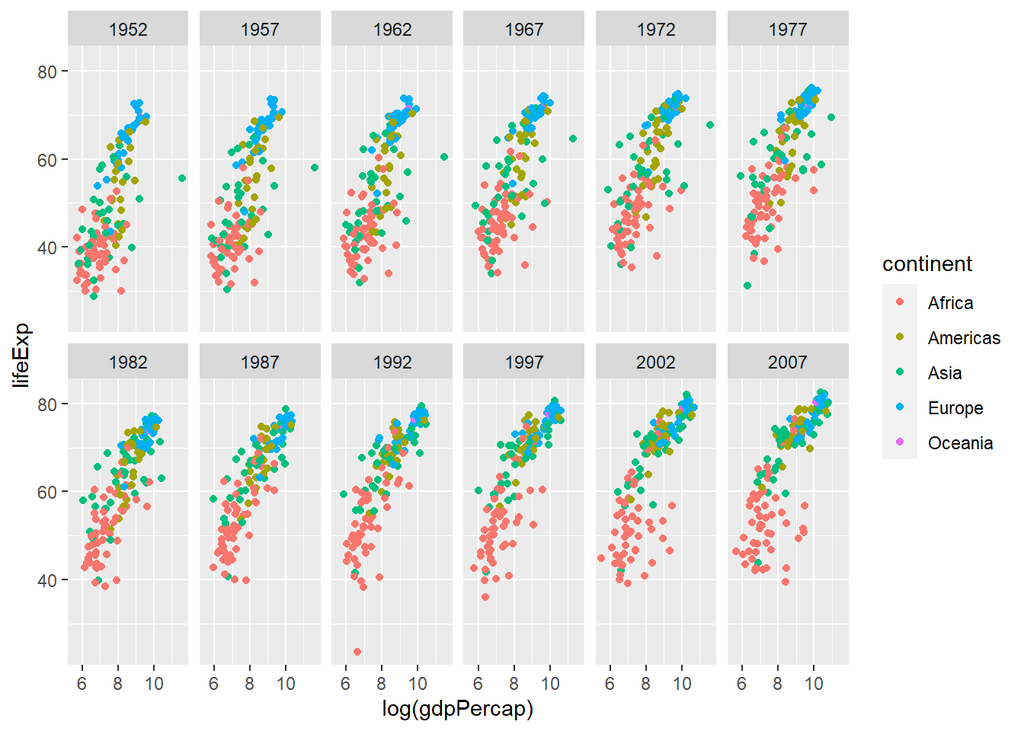

```r
ggplot(gapminder, aes(x=log(gdpPercap),y=lifeExp)) +
      geom_point(aes(color=continent)) +
      facet_wrap(~ year, nrow=2)
```

**Örnek**: Katman olarak başka geom’lar da kullanılabilir. Örneğin

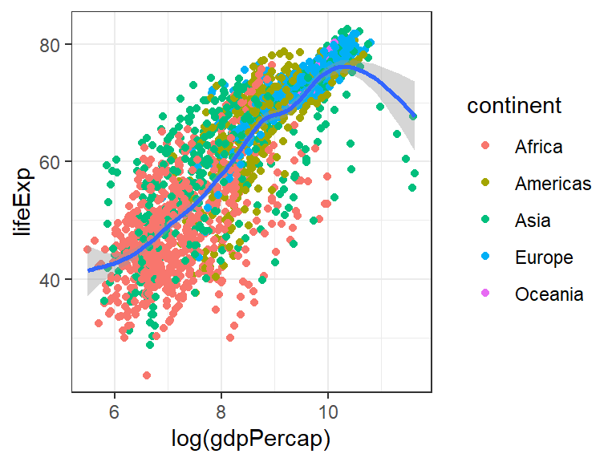

```r
ggplot(gapminder, aes(x=log(gdpPercap),y=lifeExp)) +
      geom_point(aes(color=continent)) +
      geom_smooth() +
      theme_bw()
```

**Örnek**: Loess ile Avrupa ülkelerine uydurulmuş bir eğrinin eklenmesi

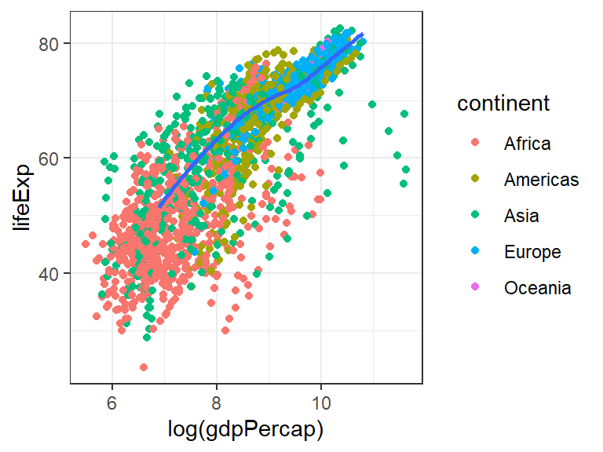

```r
ggplot(gapminder, aes(x=log(gdpPercap),y=lifeExp)) +
      geom_point(aes(color=continent)) +
      geom_smooth(data = filter(gapminder, continent == "Europe"), se=FALSE) +
      theme_bw()
```

# 5 Örnek: Türkiye’de İllerde Yaşam İndeksi Göstergeleri (2015)

```r
library(tidyverse)
library(readxl)
veriler <- read_excel("Data/mutluluk2015.xls", range = "A6:BA88")
```

`View(veriler)` ile verileri incelediğimizde bazı gözlemlerin boş olduğunu (NA) ve değişken isimlerinin çok uzun olduğunu görüyoruz. Bunun dışında veriler düzenli (tidy) formattadır.

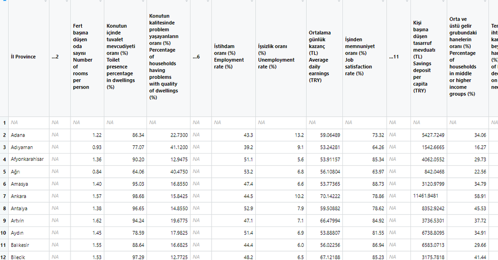

Boş sütunları silelim:

```r
# ismi "..." ile başlayan boş sütunları sil
veriler <- veriler %>%
  dplyr::select(-contains('...'))
# note: select() may not work right if MASS is package is also loaded
```

Ayrıca ilk satırı sil:

```r
veriler <- veriler %>% drop_na()
```

Şimdi elimizde 81 il için 42 değişkenden oluşan bir veri seti var. Ancak değişken isimleri çok uzun. Bunları değiştirelim.

```r
# TR isimlendirme
# mevcut veri setindeki değişken isimlerini içeren karakter vektörü
isim_tanim <- names(veriler)
```

Bu karakter vektörünü bir kenarda tutalım. Sütunlardaki değişkenlerin tanımları daha sonra gerekebilir. İhtiyaç duyduğumuzda değişkenin tam tanımına bakabiliriz. Örneğin 42nci sütundaki değişkenin tanımı:

```r
isim_tanim[42]
```

```
## [1] "Mutluluk düzeyi \n(%) \nLevel of happiness \n(%)"
```

Şimdi değişkenlere daha kısa isimler verelim:

```r
# bu karakter vektörünün elemanlarını değiştir:
isimler <- isim_tanim
isimler[1] <- "il"
isimler[2] <- "oda"
isimler[3] <- "tuv"
isimler[4] <- "ev_kalite"
isimler[5] <- "istihdam"
isimler[6] <- "issizlik"
isimler[7] <- "ort_gun_kazanc"
isimler[8] <- "is_tatmin"
isimler[9] <- "tasarruf"
isimler[10] <- "orta_ust_gelir_gr"
isimler[11] <- "temel_iht_gr"
isimler[12] <- "bebek_mort"
isimler[13] <- "yasam_bek"
isimler[14] <- "doktor_basv"
isimler[15] <- "saglik_tatmin"
isimler[16] <- "kamu_saglik_tatmin"
isimler[17] <- "okullasma_3_5"
isimler[18] <- "TEOG"
isimler[19] <- "YGS"
isimler[20] <- "yuk_egit_orani"
isimler[21] <- "kamu_egit_tatmin"
isimler[22] <- "hava_kir"
isimler[23] <- "orman_alan"
isimler[24] <- "atik_hiz"
isimler[25] <- "gurultu_kir"
isimler[26] <- "bel_temiz_tatmin"
isimler[27] <- "cinayet"
isimler[28] <- "tra_kaza"
isimler[29] <- "gece_guv_yuru"
isimler[30] <- "kamu_guv_tatmin"
isimler[31] <- "oy_verme_belediye"
isimler[32] <- "uyelik_siy_parti"
isimler[33] <- "sendika"
isimler[34] <- "internet"
isimler[35] <- "kanalizasyon"
isimler[36] <- "havaalani"
isimler[37] <- "kamu_ulasim_tatmin"
isimler[38] <- "sin_tiyatro"
isimler[39] <- "avm"
isimler[40] <- "sosyal_ilis_tatmin"
isimler[41] <- "sosyal_hayat_tatmin"
isimler[42] <- "mutluluk"
```

Sütun isimlerini değiştirelim:

```r
colnames(veriler) <- isimler
# verilere göz at
glimpse(veriler)
```

```
## Rows: 81
## Columns: 42
## $ il                  <chr> "Adana", "Adıyaman", "Afyonkarahisar", "Ağrı", "Am~
## $ oda                 <dbl> 1.22, 0.93, 1.36, 0.84, 1.40, 1.57, 1.38, 1.62, 1.~
## $ tuv                 <dbl> 86.34, 77.07, 90.20, 64.06, 95.03, 98.68, 96.65, 9~
## $ ev_kalite           <dbl> 22.7300, 41.1200, 12.9475, 40.4750, 16.8550, 15.84~
## $ istihdam            <dbl> 43.3, 39.2, 51.1, 53.2, 47.4, 44.5, 52.9, 47.1, 51~
## $ issizlik            <dbl> 13.2, 9.1, 5.6, 6.8, 6.6, 10.2, 7.9, 7.1, 6.9, 6.0~
## $ ort_gun_kazanc      <dbl> 59.06489, 53.24281, 53.91157, 56.10804, 53.77365, ~
## $ is_tatmin           <dbl> 73.32, 64.26, 85.34, 63.97, 88.73, 78.86, 78.62, 8~
## $ tasarruf            <dbl> 5427.7249, 1542.6665, 4062.0552, 842.0468, 3120.97~
## $ orta_ust_gelir_gr   <dbl> 34.06, 16.27, 29.73, 22.56, 34.79, 58.91, 45.53, 3~
## $ temel_iht_gr        <dbl> 59.77, 74.77, 44.08, 73.54, 43.75, 42.38, 48.66, 3~
## $ bebek_mort          <dbl> 13.181440, 12.061484, 9.572374, 14.432990, 15.3846~
## $ yasam_bek           <dbl> 77.39335, 79.54820, 76.99212, 75.62830, 77.76714, ~
```

[output cut: 29 more lines]

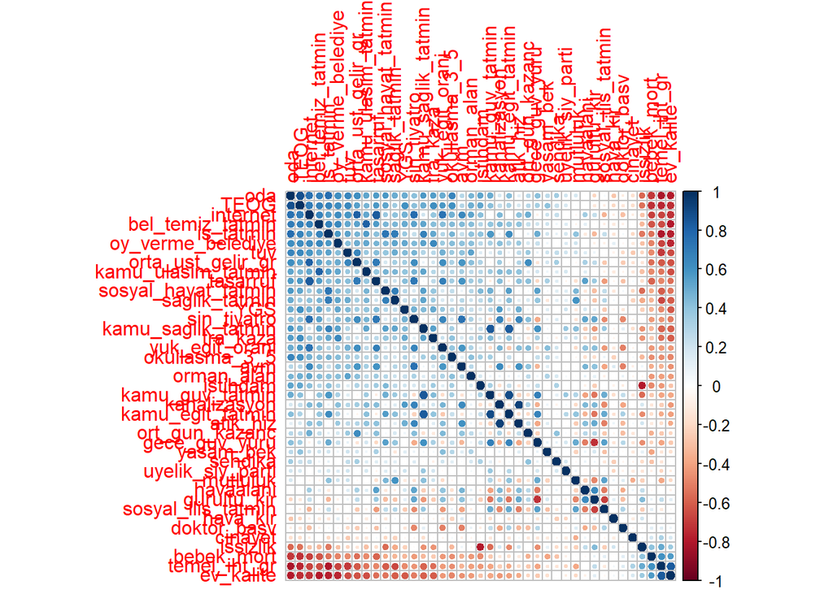

```r
library(corrplot)
corrplot(cor(veriler[-1]), is.corr=TRUE, order = "FPC")
```

Verileri daha sonra kullanmak için `RData` formatında kaydedelim:

```r
save(veriler, file = "Data/yasamveri2015.RData")
```

(Not: Yerel klasör adresini uygun şekilde değiştirebilirsiniz. Yukarıdaki kodda veri seti current dir içindeki Data klasörüne kaydedildi).

Mutluluk göstergesinin özet istatistikleri ve histogramı:

```r
summary(veriler$mutluluk)
```

```
##    Min. 1st Qu.  Median    Mean 3rd Qu.    Max.
##   41.98   56.54   60.39   61.15   65.57   77.66
```

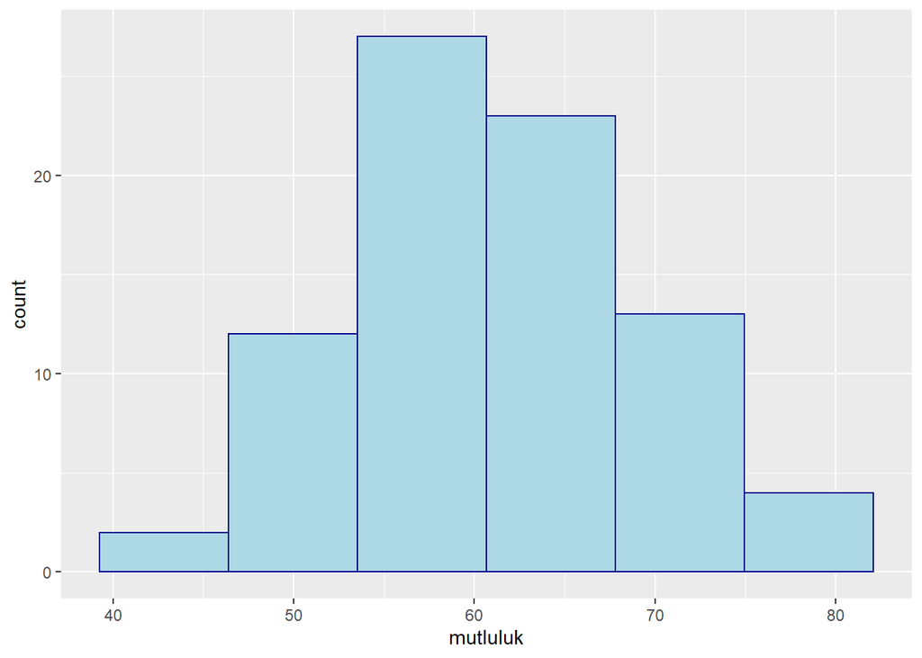

```r
veriler %>% ggplot(mapping = aes(x = mutluluk)) +
  geom_histogram(bins = 6, color = "darkblue", fill = "lightblue")
```

En mutlu iller hangileri?

```r
# list top 10 happiest provinces
veriler %>%
  select(il, mutluluk)  %>%
  arrange(desc(mutluluk)) %>%
  head(10)
```

```
## # A tibble: 10 x 2
##    il             mutluluk
##    <chr>             <dbl>
##  1 Sinop              77.7
##  2 Afyonkarahisar     76.4
##  3 Bayburt            75.9
##  4 Kırıkkale          75.5
##  5 Kütahya            73.8
##  6 Çankırı            73.5
##  7 Düzce              72.8
##  8 Uşak               72.3
##  9 Siirt              71.6
## 10 Şırnak             71.4
```

Bu tablonun (tüm iller için) grafiğini oluşturalım:

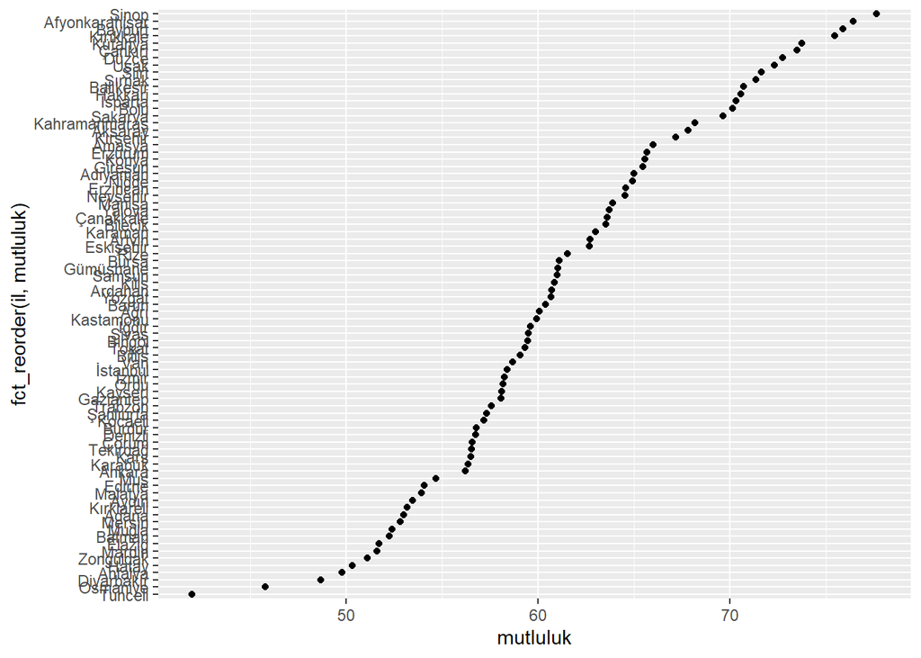

```r
ggplot(veriler, aes(x = mutluluk, y = fct_reorder(il, mutluluk))) +
  geom_point()
```

Aşağıdaki iki grafiği yorumlayınız:

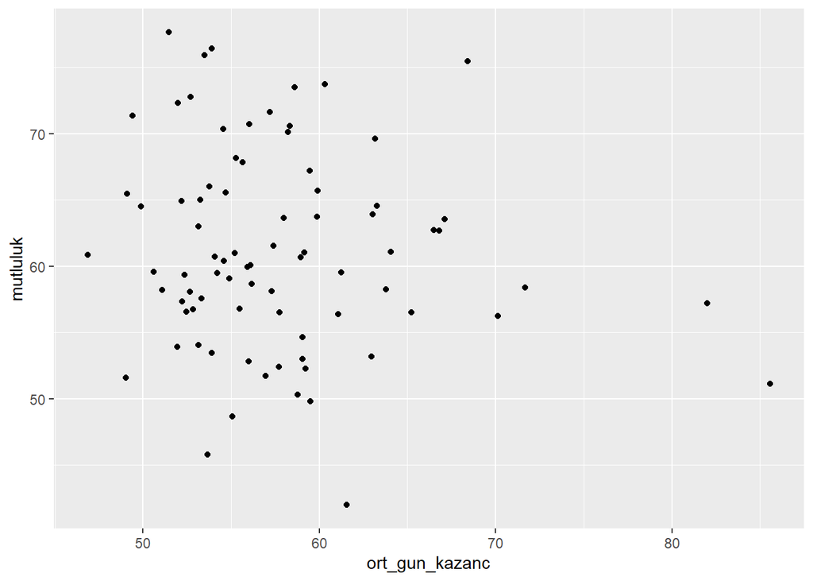

```r
# Ortalama günlük kazanç (TL) vs. Mutluluk
ggplot(veriler, aes(x=ort_gun_kazanc, y=mutluluk)) +
      geom_point()
```

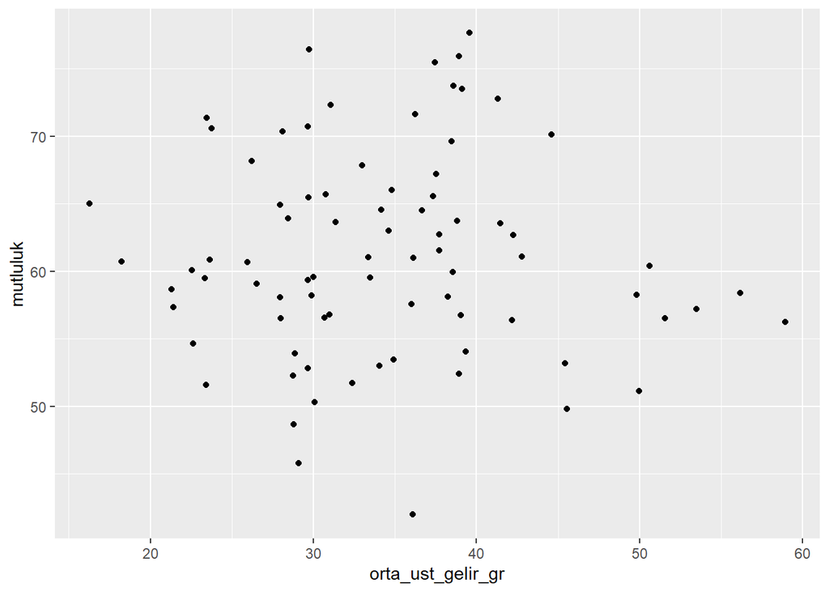

```r
# Orta ve üstü gelir grubundaki hanelerin oranı (%) vs Mutluluk
ggplot(veriler, aes(x=orta_ust_gelir_gr, y=mutluluk)) +
      geom_point()
```